# Part I - (Loan Data Exploration)

## by (Agbons Ekata-Inuaghata)

## Introduction

```python
# import all packages and set plots to be embedded inline
import numpy as np
import pandas as pd
import matplotlib.pyplot as plt
import seaborn as sb
import warnings
warnings.filterwarnings('ignore')

%matplotlib inline
```

```python
loan = pd.read_csv('prosperLoanData.csv')
```

```python
# high-level overview of data shape and composition
loan.head(5)
```

[output not shown]

5 rows × 82 columns

```python
# high-level overview of data shape and composition
loan.shape
```

```
(113610, 82)
```

```python
#Turn all columns in the new loan dataframe to lower case letters for easy analysis
loan = loan.rename(columns = str.lower)
```

> I'm most interested in figuring out the best features for predicting the borrower's interest rate for the loan.

> I expect that features such as the 'total loan amount, 'available bank credit, salary range' etc will have a negative effect on the borrowerrate of the loan: the larger the total loan amount, the lower the interest rate. I also strongly feel that the 'stated monthly income' of the borrower, loan term, Prosper rating, Prosper Score, occupation, and the employment status will also have effects on the interest rate.

## Univariate Exploration

> I'll start by understanding and exploring the distribution of the main variable of interest: borrower rate.

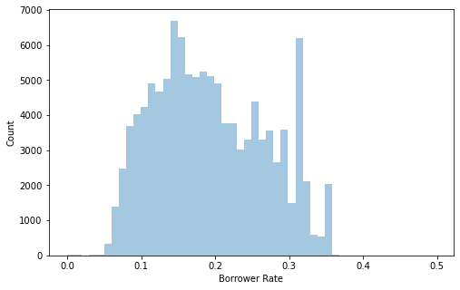

```python
plt.figure(figsize=[8, 5])
sb.distplot(loan['borrowerrate'], kde = False);
plt.xlabel('Borrower Rate');
plt.ylabel('Count');
```

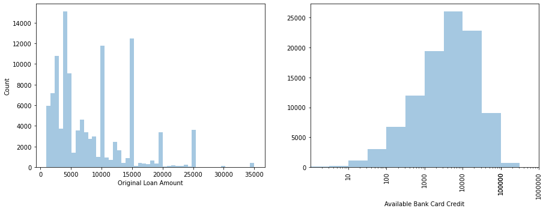

```python
#Histogram distribution for Original Loan Amount and Available Bank Card Credit
#Histogram distribution for Original Loan Amount
plt.figure(figsize = [15, 5])
plt.subplot(1, 2, 1)
sb.distplot(loan.loanoriginalamount, kde = False);
plt.xlabel('Original Loan Amount')
plt.ylabel('Count');

#Histogram distribution for Available Bank Card Credit
plt.subplot(1, 2, 2)
bins_new = 10 ** np.arange(-1, 13.379 + 2, 0.5)
sb.distplot(loan.availablebankcardcredit, kde = False, bins = bins_new);
ticks = [10, 100, 1000, 10000, 100000, 100000, 1000000]
labels = ['{}'.format(v) for v in ticks]
plt.xscale('log')
plt.xticks(ticks, labels);
plt.xticks(rotation = 90);
plt.xlim((1, 1000000))
plt.xlabel('Available Bank Card Credit');
```

For original loan amount there are very large spikes in frequency are at 5k, 10k, 15k, 20k, 25k and a little spike at 35k. Most of the loans are multiples of 5k. The available bank card credit is left skewed and mostly around the range of 10-100000.

Now, we will look at the distributions of another variable of interest: stated monthly income

[figure not shown]

```python
plt.figure(figsize=[8, 5]);
sb.distplot(loan['statedmonthlyincome'], kde = False);
plt.xlabel('Monthly Income');
plt.ylabel('Count');
```

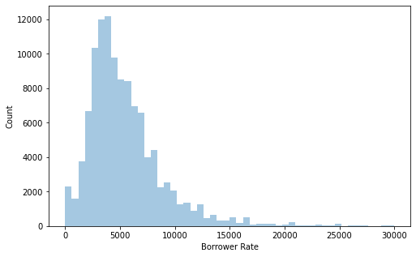

```python
plt.figure(figsize=[8, 5])
sb.distplot(loan['statedmonthlyincome'], kde = False);
plt.xlabel('Borrower Rate');
plt.ylabel('Count');
```

We have a plot that is right skewed with most of the monthly income less than 30k

```python
# Check all borrowers with stated monthly income greater than 1e5 or 100000
loan[loan.statedmonthlyincome > 1e5]
```

|  | listingkey | listingnumber | listingcreationdate | creditgrade | term | loanstatus | closeddate | borrowerapr | borrowerrate | lenderyield | ... | lp_servicefees | lp_collectionfees | lp_grossprincipalloss | lp_netprincipalloss | lp_nonprincipalrecoverypayments | percentfunded | recommendations | investmentfromfriendscount | investmentfromfriendsamount | investors |
| --- | --- | --- | --- | --- | --- | --- | --- | --- | --- | --- | --- | --- | --- | --- | --- | --- | --- | --- | --- | --- | --- |
| 8066 | 37043512916744588463B5A | 500651 | 2011-04-02 13:58:32.227000000 | NaN | 36 | Completed | 2012-01-26 00:00:00 | 0.35643 | 0.3199 | 0.3099 | ... | -6.68 | -59.23 | 0.00 | 0.00 | 0.00 | 1.0 | 0 | 0 | 0.0 | 10 |
| 8870 | 44C03374833179521CEFD7D | 66246 | 2006-11-26 00:25:07.540000000 | A | 36 | Chargedoff | 2009-08-11 00:00:00 | 0.12700 | 0.1200 | 0.1050 | ... | -91.51 | 0.00 | 3636.74 | 2614.75 | 227.06 | 1.0 | 0 | 0 | 0.0 | 105 |
| 17411 | 873B351262140884511D81C | 501462 | 2011-04-08 21:58:21.847000000 | NaN | 36 | Completed | 2013-04-11 00:00:00 | 0.35643 | 0.3199 | 0.3099 | ... | -12.68 | 0.00 | 0.00 | 0.00 | 0.00 | 1.0 | 0 | 0 | 0.0 | 128 |
| 35218 | CB0C3485937995411C24C46 | 461028 | 2010-06-01 18:34:31.423000000 | NaN | 36 | Completed | 2013-06-11 00:00:00 | 0.07389 | 0.0705 | 0.0605 | ... | -15.95 | 0.00 | 0.00 | 0.00 | 0.00 | 1.0 | 0 | 0 | 0.0 | 58 |
| 45028 | ABE935469654884447DAB6C | 589104 | 2012-05-15 12:49:18.987000000 | NaN | 36 | Current | NaN | 0.33973 | 0.2999 | 0.2899 | ... | -55.85 | 0.00 | 0.00 | 0.00 | 0.00 | 1.0 | 0 | 0 | 0.0 | 15 |
| 53014 | F5D13567265432980C80C7D | 694401 | 2013-01-04 20:02:24.207000000 | NaN | 12 | Completed | 2014-01-23 00:00:00 | 0.25785 | 0.1795 | 0.1695 | ... | -22.17 | 0.00 | 0.00 | 0.00 | 0.00 | 1.0 | 0 | 0 | 0.0 | 93 |
| 53167 | F9AD3540233111834F3D8A0 | 560783 | 2012-02-20 12:53:44.577000000 | NaN | 36 | Current | NaN | 0.35797 | 0.3177 | 0.3077 | ... | -57.63 | -59.06 | 0.00 | 0.00 | 0.00 | 1.0 | 0 | 0 | 0.0 | 2 |
| 56867 | B7FC33861182547660E2E00 | 120075 | 2007-04-06 18:12:51.793000000 | AA | 36 | Completed | 2007-05-11 00:00:00 | 0.11144 | 0.1045 | 0.0995 | ... | -7.88 | 0.00 | 0.00 | 0.00 | 0.00 | 1.0 | 0 | 0 | 0.0 | 434 |
| 57133 | BF643510331462185E12917 | 499194 | 2011-03-24 14:50:00.220000000 | NaN | 36 | Current | NaN | 0.35643 | 0.3199 | 0.3099 | ... | -70.90 | 0.00 | 0.00 | 0.00 | 0.00 | 1.0 | 0 | 0 | 0.0 | 72 |
| 59298 | 5D953538207426201B4AF6E | 558458 | 2012-02-13 07:43:35.380000000 | NaN | 36 | Current | NaN | 0.24246 | 0.2049 | 0.1949 | ... | -215.66 | 0.00 | 0.00 | 0.00 | 0.00 | 1.0 | 0 | 0 | 0.0 | 204 |
| 63925 | 8E713364810500612B4B731 | 25554 | 2006-07-19 19:09:12.950000000 | E | 36 | Completed | 2009-03-03 00:00:00 | 0.25948 | 0.2500 | 0.2450 | ... | -16.83 | 0.00 | 0.00 | 0.00 | 0.00 | 1.0 | 0 | 0 | 0.0 | 16 |
| 78431 | A6B23396838119870560CF5 | 185978 | 2007-08-12 15:49:35.860000000 | C | 36 | Chargedoff | 2009-06-21 00:00:00 | 0.20253 | 0.1952 | 0.1852 | ... | -50.13 | -94.14 | 3263.11 | 3263.11 | 0.00 | 1.0 | 0 | 0 | 0.0 | 61 |
| 80075 | 3EF13599587266423B7BC76 | 1111360 | 2014-01-14 17:01:25.710000000 | NaN | 36 | Current | NaN | 0.20217 | 0.1655 | 0.1555 | ... | -21.23 | 0.00 | 0.00 | 0.00 | 0.00 | 1.0 | 0 | 0 | 0.0 | 1 |
| 82831 | 60723558334981883FF3663 | 637992 | 2012-09-11 23:56:44.900000000 | NaN | 36 | Current | NaN | 0.31012 | 0.2710 | 0.2610 | ... | -47.41 | 0.00 | 0.00 | 0.00 | 0.00 | 1.0 | 0 | 0 | 0.0 | 6 |
| 83697 | 1FCB33802527950304EB984 | 93861 | 2007-02-05 18:37:03.927000000 | AA | 36 | Completed | 2007-04-03 00:00:00 | 0.08684 | 0.0800 | 0.0750 | ... | -3.19 | 0.00 | 0.00 | 0.00 | 0.00 | 1.0 | 0 | 0 | 0.0 | 92 |
| 111265 | 825035817683098956309D0 | 814064 | 2013-06-19 06:54:27.577000000 | NaN | 60 | Completed | 2014-02-18 00:00:00 | 0.20593 | 0.1819 | 0.1719 | ... | -80.57 | 0.00 | 0.00 | 0.00 | 0.00 | 1.0 | 0 | 0 | 0.0 | 114 |
| 113270 | D3AF357238727540198D36B | 715718 | 2013-02-20 19:23:37.430000000 | NaN | 36 | Current | NaN | 0.22712 | 0.1899 | 0.1799 | ... | -17.54 | 0.00 | 0.00 | 0.00 | 0.00 | 1.0 | 0 | 0 | 0.0 | 26 |

17 rows × 81 columns

```python
# Get the percentage of borrowers whose stated monthly income is greater than 30k
(loan.statedmonthlyincome > 30000).sum() / float(loan.shape[0])
```

```
0.002870007109191922
```

Less than 0.3 percent of the borrowers have stated monthly income greater than 30k. These can be seen as outliers for the following analysis, so it is better to remove borrower records with income greater than 30k.

```python
# remove loans with stated monthly income greater than 30k, which are outliers for this dataset
loan = loan[loan.statedmonthlyincome <= 30000]
```

```python
#Test
(loan.statedmonthlyincome > 30000).sum()
```

```
0
```

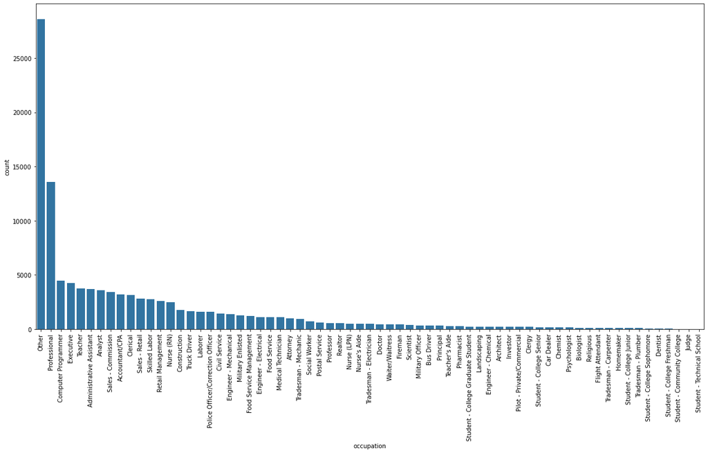

```python
#Distrubution for Occupation
plt.figure(figsize = [20, 10]);
sb.countplot(data = loan, x = 'occupation', color = base_color, order = occupation_order);
plt.xticks(rotation = 90);
occupation_order = loan.occupation.value_counts().index
```

We observe that other and professionals are the top occupations. But due to specificity, we would be utilising Computer Programmer and Teacher as the top 2 occupations

## Bivariate Exploration

> To start off with, I want to explore the relationship between year and borrrower rate across the years, then the pairwise correlations present between various features in the data.

```python
#Create a new 'year' column
#First convert loanorigination date to datetime format
loan['loanoriginationdate'] = pd.to_datetime(loan['loanoriginationdate'])

#Create year column
loan['year'] = pd.to_datetime(loan['loanoriginationdate']).dt.year
```

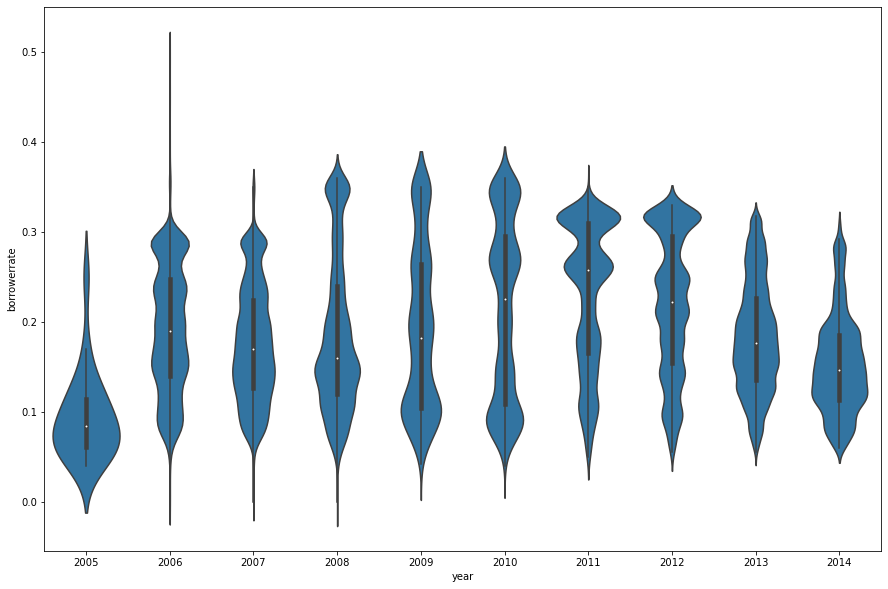

```python
plt.figure(figsize = [15, 10]);
sb.violinplot(data=loan, x='year', y='borrowerrate', color=base_color);
```

```python
numeric = ['loanoriginalamount', 'borrowerrate', 'statedmonthlyincome', 'availablebankcardcredit']
categorical = ['incomerange', 'loanstatus', 'year', 'employmentstatus']
```

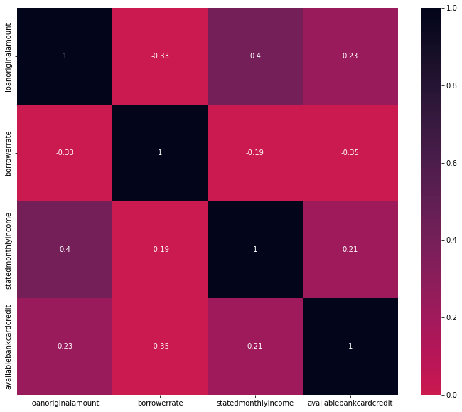

```python
# correlation plot
plt.figure(figsize = [12, 10]);
sb.heatmap(loan[numeric].corr(), cmap = 'rocket_r', annot = True, vmin = 0, center = 0);
```

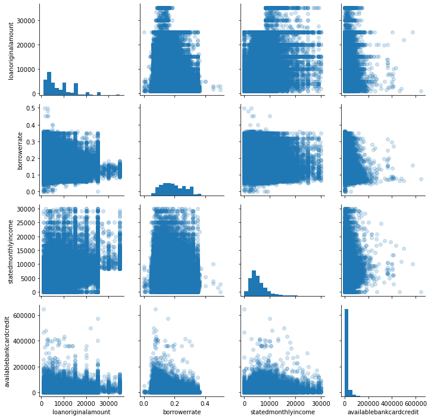

```python
g = sb.PairGrid(data = loan, vars = numeric_vars)
g = g.map_diag(plt.hist, bins=20)
g.map_offdiag(plt.scatter, alpha=0.2);
```

- There is a negative correlation between Borrowerrate and Original Loan Amount. This means that the higher the loan amount, the lower the interest rate. This will encourage borrowers to take more loans
- The loan original amount is positively correlated with the stated monthly income, it makes sense since borrowers with more monthly income could loan more money
- There is a negative correlation between Borrowerrate and Available Bank card credit. This means that the higher the available credit the borrower has, the lower the interest rate.

```python
#Convert Employment status a nd income rangeinto ordered categories
order_of_employment = ['Employed','Self-employed','Full-time','Part-time','Retired','Other','Not employed', 'Not available']
ordered_emp_rating = pd.api.types.CategoricalDtype(ordered = True, categories = order_of_employment)
loan.employmentstatus = loan.employmentstatus.astype(ordered_emp_rating)

#Income range
income_range = ['Not displayed', 'Not employed', '$0', '$1-24,999', '$25,000-49,999', '$50,000-74999', '$75,000-99,999',
               '$100,000+']
ordered_income = pd.api.types.CategoricalDtype(ordered = True, categories = income_range)
loan.incomerange = loan.incomerange.astype(ordered_income)
```